# Pinnacle Upholsters

Sales Department

# Introduction

This report describes the sales made by Pinnacle Upholsters for the month of `July` in `2014`. Goods sold are divided into `3` distinct segments,i.e `Consumer`, `Corporate` and `Home Office`. Each of these segments are further divided into `4` ship modes, namely: `First Class`, `Same Day`, `Second Class` and `Standard Class`

## Consumer

### First Class

- Total sales made: Ksh. 0

### Same Day

- Total sales made: Ksh. 0

### Second Class

- Total sales made: Ksh. 0

### Standard Class

- Total sales made: Ksh. 428.544

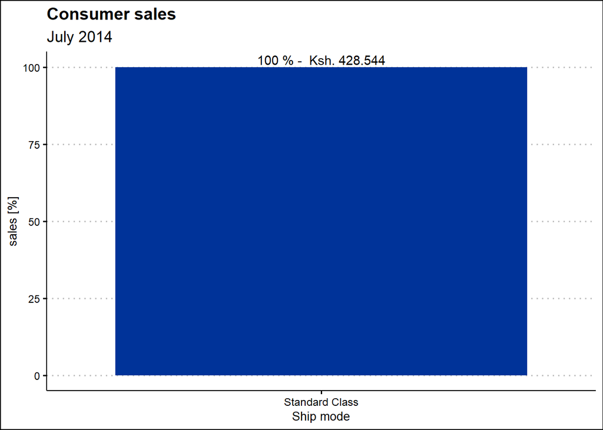

## Corporate

### First Class

- Total sales made: Ksh. 246.364

### Same Day

- Total sales made: Ksh. 0

### Second Class

- Total sales made: Ksh. 282.958

### Standard Class

- Total sales made: Ksh. 713.452

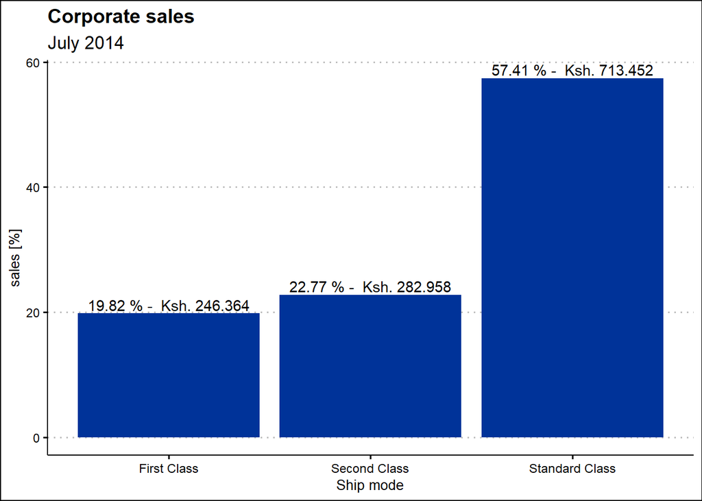

## Home Office

### First Class

- Total sales made: Ksh. 0

### Same Day

- Total sales made: Ksh. 0

### Second Class

- Total sales made: Ksh. 0

### Standard Class

- Total sales made: Ksh. 525.95

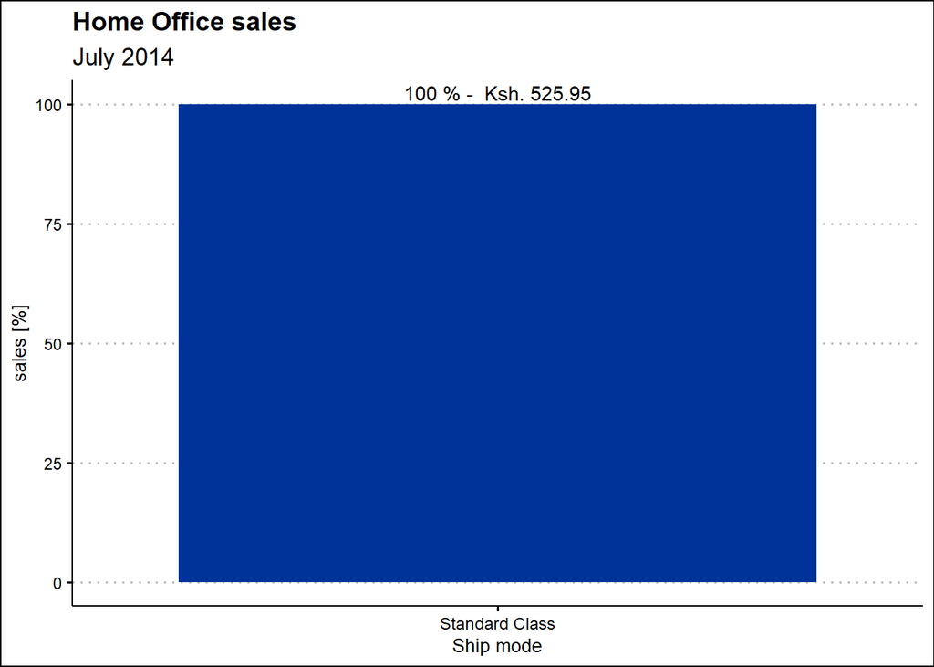

# Insights

- Total monthly sales `Ksh. 2197.268`
- Percentage change in `total monthly sales`,with respect to last month is `-74.31 %`

## Segments

- `Corporate` was the top-performing segment raking in `Ksh 1242.774` which translates to `56.56 %` of the total monthly revenue.
- `Consumer` was the biggest underperformer, bringing in `19.5 %` of the total revenue.

## Shipping modes

- `Standard Class` goods fetched `Ksh. 428.544` which is `100 %` of all the sales made from the `Consumer` segment.
- `Standard Class` goods fetched `Ksh. 713.452` which is `57.41 %` of all the sales made from the `Corporate` segment.
- `Standard Class` goods fetched `Ksh. 525.95` which is `100 %` of all the sales made from the `Home Office` segment.
- `Consumer First Class, Consumer Second Class, Consumer Same Day, Corporate Same Day, Home Office First Class, Home Office Second Class, Home Office Same Day` combinations made `no revenue` for the month.

## Customer orders

- Total number of orders: `12`
  - `Corporate`: `58.33 %`
  - `Consumer`: `33.33 %`
  - `Home Office`: `8.33 %`
- The average value of orders made in Ksh.:

  | segment | average_order_value |
  | --- | --- |
  | Home Office | 525.9500 |
  | Corporate | 177.5391 |
  | Consumer | 107.1360 |